# Tablas de frecuencias y contingencias

Maestría en Ciencia de Datos

2024

## Tablas de frecuencias

Una tabla de frecuencias muestra el conteo de observaciones para cada categoría de una variable. Usaremos la función table() para crear una.

Ejemplo 1: Tabla de Frecuencias Simple

Supongamos que tienes un vector de datos categóricos y quieres conocer la frecuencia de cada categoría.

```r
# Vector de ejemplo
colores <- c("rojo", "azul", "verde", "azul", "rojo", "verde", "verde", "azul")

# Crear tabla de frecuencias
tabla_frecuencias <- table(colores)
print(tabla_frecuencias)
```

```
## colores
##  azul  rojo verde
##     3     2     3
```

### Tablas de Contingencia

Las tablas de contingencia son útiles para examinar la relación entre dos variables categóricas. También utilizamos table() para esto.

Ejemplo 2: Tabla de Contingencia

Imagina que tienes dos vectores categóricos y deseas explorar cómo se relacionan entre sí.

```r
# Dos vectores de ejemplo
genero <- c("F", "M", "F", "F", "M", "M", "F", "M")
color_preferido <- c("rojo", "azul", "verde", "azul", "rojo", "verde", "verde", "azul")

# Crear tabla de contingencia
tabla_contingencia <- table(genero, color_preferido)
print(tabla_contingencia)
```

```
##       color_preferido
## genero azul rojo verde
##      F    1    1     2
##      M    2    1     1
```

## Frecuencias Relativas

A veces, es útil ver las frecuencias relativas en lugar de los conteos absolutos.

Ejemplo 3: Frecuencias Relativas en Tabla de Contingencia

```r
# Convertir a frecuencias relativas
frecuencias_relativas <- prop.table(tabla_contingencia)
print(frecuencias_relativas)
```

```
##       color_preferido
## genero  azul  rojo verde
##      F 0.125 0.125 0.250
##      M 0.250 0.125 0.125
```

### Tablas de Contingencia con Más de Dos Variables

Puedes crear tablas de contingencia con más de dos variables para explorar relaciones más complejas.

Ejemplo 4: Tabla de Contingencia de Tres Vías

```r
# Un tercer vector de ejemplo
edad_grupo <- c("adulto", "adulto", "joven", "joven", "adulto", "joven", "joven", "adulto")

# Crear tabla de contingencia de tres vías
tabla_contingencia_3d <- table(genero, color_preferido, edad_grupo)
print(tabla_contingencia_3d)
```

```
## , , edad_grupo = adulto
##
##       color_preferido
## genero azul rojo verde
##      F    0    1     0
##      M    2    1     0
##
## , , edad_grupo = joven
##
##       color_preferido
## genero azul rojo verde
##      F    1    0     2
##      M    0    0     1
```

### Visualizar Tablas de Contingencia

Finalmente, puedes visualizar estas tablas usando paquetes como ggplot2 para una mejor interpretación.

Ejemplo 5: Visualización con ggplot2

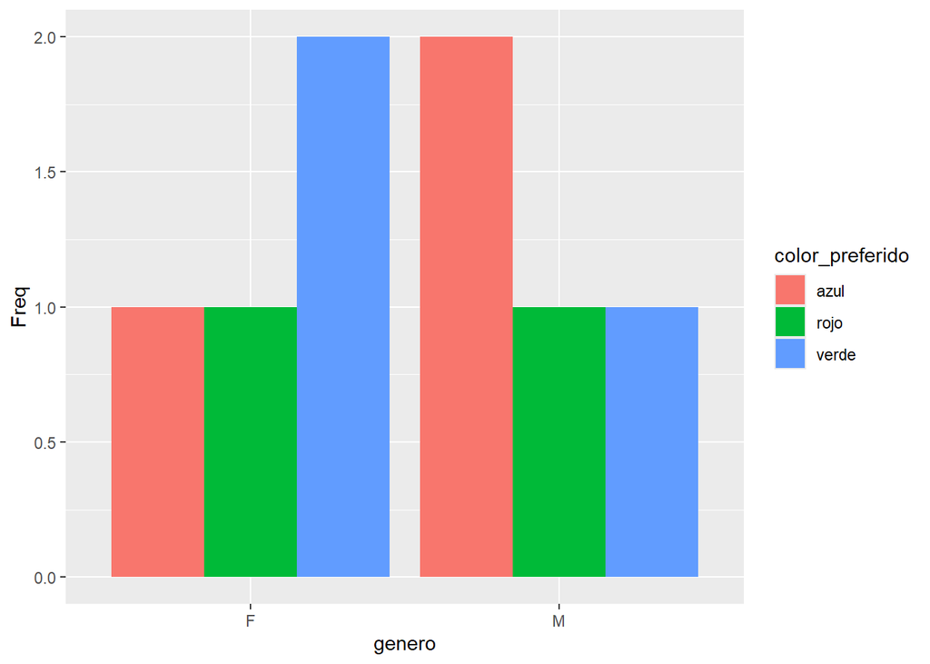

```r
library(ggplot2)
# Convertir la tabla de contingencia a formato de dataframe para ggplot
df_contingencia <- as.data.frame(table(genero, color_preferido))

# Crear gráfico de barras
ggplot(df_contingencia, aes(x = genero, y = Freq, fill = color_preferido)) +
  geom_bar(stat = "identity", position = position_dodge())
```

## Knitr kable

kable es una función del paquete knitr que proporciona una forma sencilla de convertir un objeto R en una tabla HTML/LaTeX.

```r
library(knitr)

kable(tabla_contingencia)
```

|  | azul | rojo | verde |
| --- | --- | --- | --- |
| F | 1 | 1 | 2 |
| M | 2 | 1 | 1 |

### xtable

xtable convierte una tabla de R a formato HTML/LaTeX, ofreciendo opciones más avanzadas de formato.

```r
library(xtable)

print(xtable(tabla_contingencia), type = "latex")
```

```
## % latex table generated in R 4.4.1 by xtable 1.8-4 package
## % Sun Jan 12 23:35:52 2025
## \begin{table}[ht]
## \centering
## \begin{tabular}{rrrr}
##   \hline
##  & azul & rojo & verde \\
##   \hline
## F &   1 &   1 &   2 \\
##   M &   2 &   1 &   1 \\
##    \hline
## \end{tabular}
## \end{table}
```

### ftable

ftable es útil para tablas de contingencia de mayor dimensionalidad, ya que presenta los datos en un formato más compacto y fácil de leer.

```r
ftable(tabla_contingencia)
```

```
##        color_preferido azul rojo verde
## genero
## F                         1    1     2
## M                         2    1     1
```

### DT::datatable

datatable del paquete DT es especialmente útil para tablas interactivas en aplicaciones web y Shiny.

```r
library(DT)

datatable(as.data.frame.matrix(tabla_contingencia))
```

|  | azul | rojo | verde |
| --- | --- | --- | --- |
| F | 1 | 1 | 2 |
| M | 2 | 1 | 1 |

## Frecuencias absolutas, relativas y acumuladas

Crear una tabla de frecuencias que muestre la frecuencia absoluta, frecuencia acumulada, frecuencia relativa y frecuencia relativa acumulada es un ejercicio útil para entender la distribución de los datos.

### Datos de ejemplo

```r
datos <- c("A", "B", "A", "C", "B", "A", "A", "B", "C", "C", "B", "A", "B", "C", "A")
```

### Absolutas

```r
tabla_absoluta <- table(datos)
print(tabla_absoluta)
```

```
## datos
## A B C
## 6 5 4
```

### Acumuladas

```r
frec_acumulada <- cumsum(tabla_absoluta)
print(frec_acumulada)
```

```
##  A  B  C
##  6 11 15
```

### Relativas

```r
frec_relativa <- prop.table(tabla_absoluta)
print(frec_relativa)
```

```
## datos
##         A         B         C
## 0.4000000 0.3333333 0.2666667
```

### Relativas acumuladas

```r
frec_relativa_acumulada <- cumsum(frec_relativa)
print(frec_relativa_acumulada)
```

```
##         A         B         C
## 0.4000000 0.7333333 1.0000000
```

### Combinando

```r
tabla_frecuencias <- data.frame(
  Frecuencia_Absoluta = tabla_absoluta,
  Frecuencia_Acumulada = frec_acumulada,
  Frecuencia_Relativa = round(frec_relativa*100, 1),
  Frecuencia_Relativa_Acumulada = round(frec_relativa_acumulada*100, 1)
)

print(tabla_frecuencias)
```

```
##   Frecuencia_Absoluta.datos Frecuencia_Absoluta.Freq Frecuencia_Acumulada
## A                         A                        6                    6
## B                         B                        5                   11
## C                         C                        4                   15
##   Frecuencia_Relativa.datos Frecuencia_Relativa.Freq
## A                         A                     40.0
## B                         B                     33.3
## C                         C                     26.7
##   Frecuencia_Relativa_Acumulada
## A                          40.0
## B                          73.3
## C                         100.0
```

## Tablas de contingencia: Test de independencias

La asociación estadística usando chi-cuadrado se construye a partir de la comparación entre los valores observados en una tabla de contingencia y los valores esperados bajo la hipótesis nula de independencia entre las variables categóricas. Aquí tienes una guía paso a paso para calcularlo:

Pasos para calcular la prueba de Chi-cuadrado Definir las hipótesis:

- Hipótesis nula ($H_0$): Las dos variables son independientes (no están asociadas).
- Hipótesis alternativa ($H_a$): Las dos variables no son independientes (hay asociación).

Paso 1: Se calculan las frecuencias esperadas (Eij): Bajo la hipótesis nula, los valores esperados se calculan como:

$$E_{ij}=\frac{(Total fila i)\times(Total columna j)}{(Total general)}$$

Paso 2: Calcular la contribución al estadístico Chi-cuadrado para cada celda:

$$Contribución = \frac{(O_{ij}-E{ij})^2}{E_{ij}}$$

Paso 3: Se suman las contribuciones de todas las celdas, construyendo el estadístico Chi Cuadrado:

$$\chi^2 = \sum \frac{(O_{ij}-E{ij})^2}{E_{ij}}$$

Paso 4: Se determinan los grados de libertad y se busca el pvalor asociado al estadístico:

$$df = ((filas−1)×(columnas−1))$$

Y por consiguiente se ubica el p-valor asociado.

- Si el p-valor es menor que el nivel de significancia ($\alpha$, generalmente 0.05), rechazamos $H_0$ y concluimos que hay una asociación significativa entre las variables.
- Si el p-valor es mayor que $\alpha$, no rechazamos $H_0$ y concluimos que las variables son independientes.

Aplicamos con los datos. Existen 2 maneras:

#### chisq.test

Dataset

```r
set.seed(123)
d <- data.frame(ID = 1:2000,
                edad = floor(runif(2000, min = 18, max = 65)),
                escolaridad = floor(runif(2000, min = 1, max = 19)),
                hijos = floor(runif(2000, min = 0, max = 5)),
                ingresos = floor(runif(2000, min = 1130, max = 5000)),
                sexo = sample(c("Hombre", "Mujer"), size = 2000, replace = TRUE),
                ciudad = sample(c("Lima", "Arequipa", "Huancayo", "Trujillo", "Iquitos"), size = 2000, replace = TRUE))
head(d)
```

```
##   ID edad escolaridad hijos ingresos   sexo   ciudad
## 1  1   31           3     1     2833  Mujer Huancayo
## 2  2   55           3     4     2667 Hombre Trujillo
## 3  3   37           3     2     2567 Hombre     Lima
## 4  4   59          10     4     3176  Mujer Trujillo
## 5  5   62           9     1     1415  Mujer Arequipa
## 6  6   20          12     0     3904 Hombre Huancayo
```

```r
tabla <- table(d$sexo, d$ciudad)
print(tabla)
```

```
##
##          Arequipa Huancayo Iquitos Lima Trujillo
##   Hombre      205      226     221  208      176
##   Mujer       205      186     200  222      151
```

```r
# Prueba de Chi-cuadrado
resultado <- chisq.test(tabla)

# Mostrar resultados
print(resultado)
```

```
##
##  Pearson's Chi-squared test
##
## data:  tabla
## X-squared = 4.7122, df = 4, p-value = 0.3181
```

#### librería gmodels

```r
library(gmodels)
# Tabla de contingencia con chi-cuadrado
CrossTable(d$sexo, d$ciudad, chisq = TRUE, prop.chisq = TRUE)
```

```
##
##
##    Cell Contents
## |-------------------------|
## |                       N |
## | Chi-square contribution |
## |           N / Row Total |
## |           N / Col Total |
## |         N / Table Total |
## |-------------------------|
##
##
## Total Observations in Table:  2000
##
##
##              | d$ciudad
##       d$sexo |  Arequipa |  Huancayo |   Iquitos |      Lima |  Trujillo | Row Total |
## -------------|-----------|-----------|-----------|-----------|-----------|-----------|
##       Hombre |       205 |       226 |       221 |       208 |       176 |      1036 |
##              |     0.256 |     0.742 |     0.039 |     0.975 |     0.258 |           |
##              |     0.198 |     0.218 |     0.213 |     0.201 |     0.170 |     0.518 |
##              |     0.500 |     0.549 |     0.525 |     0.484 |     0.538 |           |
##              |     0.102 |     0.113 |     0.110 |     0.104 |     0.088 |           |
## -------------|-----------|-----------|-----------|-----------|-----------|-----------|
##        Mujer |       205 |       186 |       200 |       222 |       151 |       964 |
##              |     0.276 |     0.797 |     0.042 |     1.048 |     0.278 |           |
##              |     0.213 |     0.193 |     0.207 |     0.230 |     0.157 |     0.482 |
##              |     0.500 |     0.451 |     0.475 |     0.516 |     0.462 |           |
##              |     0.102 |     0.093 |     0.100 |     0.111 |     0.075 |           |
## -------------|-----------|-----------|-----------|-----------|-----------|-----------|
## Column Total |       410 |       412 |       421 |       430 |       327 |      2000 |
##              |     0.205 |     0.206 |     0.210 |     0.215 |     0.164 |           |
## -------------|-----------|-----------|-----------|-----------|-----------|-----------|
##
##
## Statistics for All Table Factors
##
##
## Pearson's Chi-squared test
## ------------------------------------------------------------
## Chi^2 =  4.712237     d.f. =  4     p =  0.3181178
##
##
##
```

### Con datos de empleo: informalidad versus nivel educativo

```r
ruta <- 'E:/EX ONEDRIVE UAI/consultorias 2024/docencia 2024/ucontinental/1 mds/1_modelosestadisticos/v2/u3/Data/'
epen <- read.csv(paste0(ruta, 'epen2023.csv'), sep = ',', encoding = 'UTF-8')
```

```r
CrossTable(epen$AREA, epen$Informal_P, chisq = TRUE, prop.chisq = TRUE)
```

```
##
##
##    Cell Contents
## |-------------------------|
## |                       N |
## | Chi-square contribution |
## |           N / Row Total |
## |           N / Col Total |
## |         N / Table Total |
## |-------------------------|
##
##
## Total Observations in Table:  189567
##
##
##              | epen$Informal_P
##    epen$AREA |         1 |         2 | Row Total |
## -------------|-----------|-----------|-----------|
##            1 |    109493 |     57743 |    167236 |
##              |   263.801 |   580.786 |           |
##              |     0.655 |     0.345 |     0.882 |
##              |     0.840 |     0.975 |           |
##              |     0.578 |     0.305 |           |
## -------------|-----------|-----------|-----------|
##            2 |     20864 |      1467 |     22331 |
##              |  1975.598 |  4349.486 |           |
##              |     0.934 |     0.066 |     0.118 |
##              |     0.160 |     0.025 |           |
##              |     0.110 |     0.008 |           |
## -------------|-----------|-----------|-----------|
## Column Total |    130357 |     59210 |    189567 |
##              |     0.688 |     0.312 |           |
## -------------|-----------|-----------|-----------|
##
##
## Statistics for All Table Factors
##
##
## Pearson's Chi-squared test
## ------------------------------------------------------------
## Chi^2 =  7169.672     d.f. =  1     p =  0
##
## Pearson's Chi-squared test with Yates' continuity correction
## ------------------------------------------------------------
## Chi^2 =  7168.371     d.f. =  1     p =  0
##
##
```

```r
chisq.test(table(epen$AREA, epen$Informal_P))
```

```
##
##  Pearson's Chi-squared test with Yates' continuity correction
##
## data:  table(epen$AREA, epen$Informal_P)
## X-squared = 7168.4, df = 1, p-value < 2.2e-16
```

```r
CrossTable(epen$C366, epen$Informal_P, chisq = TRUE, prop.chisq = TRUE)
```

```
##
##
##    Cell Contents
## |-------------------------|
## |                       N |
## | Chi-square contribution |
## |           N / Row Total |
## |           N / Col Total |
## |         N / Table Total |
## |-------------------------|
##
##
## Total Observations in Table:  189567
##
##
##              | epen$Informal_P
##    epen$C366 |         1 |         2 | Row Total |
## -------------|-----------|-----------|-----------|
##            1 |      2273 |        85 |      2358 |
##              |   261.771 |   576.316 |           |
##              |     0.964 |     0.036 |     0.012 |
##              |     0.017 |     0.001 |           |
##              |     0.012 |     0.000 |           |
## -------------|-----------|-----------|-----------|
##            2 |       117 |         6 |       123 |
##              |    12.425 |    27.355 |           |
##              |     0.951 |     0.049 |     0.001 |
##              |     0.001 |     0.000 |           |
##              |     0.001 |     0.000 |           |
## -------------|-----------|-----------|-----------|
##            3 |     10892 |       672 |     11564 |
##              |  1086.918 |  2392.964 |           |
##              |     0.942 |     0.058 |     0.061 |
##              |     0.084 |     0.011 |           |
##              |     0.057 |     0.004 |           |
## -------------|-----------|-----------|-----------|
##            4 |     12142 |      1149 |     13291 |
##              |   986.268 |  2171.373 |           |
##              |     0.914 |     0.086 |     0.070 |
##              |     0.093 |     0.019 |           |
```

[output cut: 49 more lines]

```
## -------------|-----------|-----------|-----------|
## Column Total |    130357 |     59210 |    189567 |
##              |     0.688 |     0.312 |           |
## -------------|-----------|-----------|-----------|
##
##
## Statistics for All Table Factors
##
##
## Pearson's Chi-squared test
## ------------------------------------------------------------
## Chi^2 =  46109.37     d.f. =  11     p =  0
##
##
##
```

```r
chisq.test(table(epen$C366, epen$Informal_P))
```

```
##
##  Pearson's Chi-squared test
##
## data:  table(epen$C366, epen$Informal_P)
## X-squared = 46109, df = 11, p-value < 2.2e-16
```